# 05: Matrix Algebra and Linear Models

The foundation for all that follows!

Dean Adams, Iowa State University

# Matrices: The Algebra of Statistics

Grasping matrix algebra is the KEY for understanding statistics

Compact method of expressing mathematical operations

Generalize from one to many variables (i.e. vectors to matrices)

Matrix operations have geometric interpretations in data spaces

Much of our data (e.g., shape) cannot be measured with a single variable, so multivariate methods are required to properly address our hypotheses (e.g., can evaluate covariance)

# Scalars and Vectors

Scalars: numbers

$$\small{a} = 5$$
$$\small{b} = 2$$
$$\small{c} = -3$$

Vectors: an ordered list (array) of numbers ($\small{n}_{rows}\times{1}_{columns}$)

$$\small{\mathbf{a}} = \begin{bmatrix}
5 \\
3 \\
-2
\end{bmatrix}$$

Vector transpose: exchange the rows and columns

$$\small{\mathbf{a}^T} = \begin{bmatrix}
5 & 3 & -2
\end{bmatrix}$$

The superscript, $\small^T$, means vector transpose. Note, $\small{\left(\mathbf{a}^T \right)^T = \mathbf{a}}$

# Vector Addition and Subtraction

Same as in scalar algebra (elementwise)

Vector addition/subtraction (consistent orientation is important)

$$\small{\mathbf{a}^T} = \begin{bmatrix}
5 & 3 & -2
\end{bmatrix}$$

$$\small\mathbf{b}^T = \begin{bmatrix}
-5 & 0 & 1
\end{bmatrix}$$

$$\small\mathbf{a}^T + \mathbf{b}^T= \begin{bmatrix}
0 & 3 & -1
\end{bmatrix}$$

$$\small\mathbf{a} - \mathbf{b} = \begin{bmatrix}
10 \\ 3 \\ -3
\end{bmatrix}$$

# Vector Multiplication

So if addition and subtraction are elementwise, shouldn’t multiplication be the same?

$\small{\mathbf{a}}\times{\mathbf{b}}={\mathbf{ab}}$

$\small\begin{bmatrix} 5 \\ 3 \\ -2 \end{bmatrix}$ $\small\times$ $\small \begin{bmatrix} -5 \\ 0 \\ 1 \end{bmatrix}$ $\small{=}$ $\small \begin{bmatrix} -25 \\ 0 \\ -2 \end{bmatrix}$

**No!**

###### Actually, this is not always wrong, but is quite unusual. The above is known as the ‘Hadamard’ product (element-wise multiplication), which is a special multiplication procedure that is only possible for vectors/matrices of the same dimension (and only done when specified as Hadamard product).

# Vector Multiplication

Vector multiplication is both multiplication and summation of scalars. Before performing vector multiplication, there has to be consistency with **inner dimensions** of the vectors being multiplied.

Visually this is seen with the following example: $\small{\mathbf{a}^T}\times{\mathbf{b}}$

$\small\begin{bmatrix} a_{1} & a_{2} & \dots a_{n} \end{bmatrix} \times \begin{bmatrix} b_{1} \\ b_{2} \\ \dots \\ b_{n} \end{bmatrix} = a_{1}b_{1}+a_{2}b_{2}+\dots+a_{n}b_{n}=\sum{ab}$

- Here, $\small{\mathbf{a}^T}$ is a $\small{1 \times n}$ vector, and $\small{\mathbf{b}}$ is a $\small{n \times 1}$ vector
  - The **inner** dimensions are $\small\left({n} \times n\right)$. Found by lining up the vector dimensions: $\small{1 \times \color{red}{n} \times \color{red}{n} \times 1}$
  - The **outer** dimensions are $\small\left({1} \times 1\right)$. Found by lining up the vector dimensions: $\small{\color{red}{1} \times n \times n \times \color{red}{1}}$
- Thus, we are multiplying each of the $\small{n}$ elements in $\small{\mathbf{a}^T}$ times each of the $\small{n}$ elements in $\small{\mathbf{b}}$ and summing them
- The output is a scalar ($\small{1 \times 1}$ dimensions). This is called an *inner product*

# Vector Multiplication (cont.): Vector Inner-products

- If inner dimensions match, the multiplication is possible. The product has dimensions equal to the outer dimensions of the match. There are two types of products:
  - Inner-product: the vector product results is a single scalar, i.e., the outer dimensions are $\small{1} \times 1$
  - Outer-product: the vector product results in a series of scalar products with number and arrangement defined by outer dimensions. This creates a **matrix**

#### Vector Inner-Product

For $\small{n} \times 1$ vectors: $\small\mathbf{a}^T \mathbf{b} = \sum_{i=1}^n a_ib_i$

For example, for the vectors: $\small\mathbf{a}^T = \begin{bmatrix} 5 & 3 & -2 \end{bmatrix}$ & $\small\mathbf{b} = \begin{bmatrix} -5 \\ 0 \\ 1 \end{bmatrix}$

$\small\mathbf{a}^T \mathbf{b} = \left(5\times -5 \right) + \left(3 \times 0 \right) + \left(-2 \times 1 \right) = -27$

###### *Helpful mnemonic: “Run Amok Computational Demon!” for row-across and column-down pattern (will be helpful for matrices)*

# Vector Multiplication (cont.): Vector Outer Products

- If inner dimensions match, the multiplication is possible. The product has dimensions equal to the outer dimensions of the match. There are two types of products:
  - Inner-product: the vector product results is a single scalar, i.e., the outer dimensions are $\small{1} \times 1$
  - Outer-product: the vector product results in a series of scalar products with number and arrangement defined by outer dimensions. This creates a **matrix**

#### Vector Outer-Product

For $\small{n} \times 1$ vectors

$$\tiny\mathbf{a}\mathbf{b}^T = \begin{bmatrix}
a_1b_1 & a_1b_2 & a_1b_3 & \cdots & a_1b_n\\
a_2b_1 & a_2b_2 & a_2b_3 & \cdots & a_2b_n\\
a_3b_1 & a_3b_2 & a_3b_3 & \cdots & a_3b_n\\
\vdots & \vdots & \vdots & \ddots & \vdots\\
a_nb_1 & a_nb_2 & a_nb_3 & \cdots & a_nb_n\\
\end{bmatrix} =
\mathbf{M}_{n \times n}$$

# Vector Multiplication (cont.): Vector Outer Products

### Important Notes

$$\tiny\mathbf{a}\mathbf{b}^T = \begin{bmatrix}
a_1b_1 & a_1b_2 & a_1b_3 & \cdots & a_1b_n\\
a_2b_1 & a_2b_2 & a_2b_3 & \cdots & a_2b_n\\
a_3b_1 & a_3b_2 & a_3b_3 & \cdots & a_3b_n\\
\vdots & \vdots & \vdots & \ddots & \vdots\\
a_nb_1 & a_nb_2 & a_nb_3 & \cdots & a_nb_n\\
\end{bmatrix} =
\mathbf{M}_{n \times n}$$

- $\small\mathbf{M}$ is called a matrix, with dimensions defined
- $\small\mathbf{M}$ comprises row vectors and column vectors
- because $\small\mathbf{M}$ has the same number of rows and columns, it also has a diagonal vector
- the sum of the diagonal vector, called the **trace**, is the inner-product of $\small\mathbf{a}$ and $\mathbf{b}$

# Matrices

A matrix is more than a vector outer-product (more precisely, a vector outer-product is merely one type of matrix). A matrix is a collection of vectors, arranged in a specific way, such that linear algebra operations can be carried out as systematic operations. For example, the arrangement of vectors in a matrix indicates how to find a series of inner-products and display their results.

The most basic matrices ($\small{n \times p}$) for statistics are **data frames**. In data frames, the row vectors $\small{n}$ are the observations and the column vectors $\small{p}$ are the variables. We can demonstrate this easily in R with the *data.frame* and *matrix* functions.

```r
y1 <- c(2, 3, 2, 5, 6, 8) # variable 1 with 6 observations
y2 <- c(-1, -2, 0, 0, 1, -1) # variable 2 with 6 observations
Y <- data.frame(y1 = y1, y2 = y2)
rownames (Y) <- paste("obs", 1:6, sep = ".") # giving our observations some names
Y
```

```
##       y1 y2
## obs.1  2 -1
## obs.2  3 -2
## obs.3  2  0
## obs.4  5  0
## obs.5  6  1
## obs.6  8 -1
```

# Matrices (Cont.)

```r
Y
```

```
##       y1 y2
## obs.1  2 -1
## obs.2  3 -2
## obs.3  2  0
## obs.4  5  0
## obs.5  6  1
## obs.6  8 -1
```

Which is R’s way of saying,

$$\tiny{\mathbf{Y} = \begin{bmatrix}
2 & -1 \\
3 & -2 \\
2 & 0 \\
5 & 0 \\
6 & 1 \\
8 & -1 \\
\end{bmatrix}}$$

$\small\mathbf{Y}$ is a matrix and a data frame. Row vectors are observations for the variables represented as column vectors. The dimensions of $\small\mathbf{Y}$ are $\small n \times p$ for the $\small n$ observations of subjects for $\small p$ variables.

# Matrix Addition, Subtraction, Multiplication

### Matrix addition and subtraction

Matrix addition and subtraction is no different than vector addition and subtraction. Matrices have to have *commensurate* dimensions (same $\small{n} \times p$).

### Matrix multiplication

Matrix multiplication is nothing more than systematic calculation of vector inner-products and arrangement of these into precise corresponding elements of a new matrix. Like vectors, inner dimensions must match and the product is defined by the outer dimensions. The simplest way to define this is as follows

Let $\small{\mathbf{X}}$ be an $\small{n} \times k$ matrix and let $\small\mathbf{Y}$ by an $\small n \times p$ matrix, such that

$$\small \mathbf{X} = \begin{bmatrix}
\mathbf{x}_1 &
\mathbf{x}_2 &
\cdots &
\mathbf{x}_k
\end{bmatrix}$$
and

$$\small\mathbf{Y} = \begin{bmatrix}
\mathbf{y}_1 &
\mathbf{y}_2 &
\cdots &
\mathbf{y}_p
\end{bmatrix}$$
Note that each $\small\mathbf{x}_i$ column vector is $\small n \times 1$ in dimension for $\small k$ vectors and each $\small\mathbf{y}_i$ is $\small n \times 1$ in dimension for $p$ vectors. Thus, we could multiply as:

# Matrix Addition, Subtraction, Multiplication (Cont.)

$$\tiny\mathbf{X}^T\mathbf{Y} = \begin{bmatrix}
\mathbf{x}_1^T\mathbf{y}_1 & \mathbf{x}_1^T\mathbf{y}_2 & \cdots & \mathbf{x}_1^T\mathbf{y}_p\\
\mathbf{x}_2^T\mathbf{y}_1 & \mathbf{x}_2^T\mathbf{y}_2 & \cdots & \mathbf{x}_2^T\mathbf{y}_p\\
\vdots & \vdots & & \vdots\\
\mathbf{x}_k^T\mathbf{y}_1 & \mathbf{x}_k^T\mathbf{y}_2 & \cdots & \mathbf{x}_k^T\mathbf{y}_p\\
\end{bmatrix}$$

The matrix product is a matrix with $\small k \times p$ inner-products

In the case above, we could **NOT** multiply $\small\mathbf{YX}$ because the inner dimensions do not agree ($\small n \times p \times k \times n$).

**NOTE: ORDER OF MATRICES MATTERS: typically $\small\mathbf{XY}\neq\mathbf{YX}$**

###### Sometimes, only one of these ordered operations is possible (recall inner-dimensions must agree!)

# Matrix Multiplication (Cont.)

### Matrix multiplication example (using R script)

```r
y1 <- c(2, 3, 2, 5, 6, 8) # variable y1 with 6 observations
y2 <- c(-1, -2, 0, 0, 1, -1) # variable y2 with 6 observations
Y <- as.matrix(data.frame(y1 = y1, y2 = y2))  # R needs to know that this is precisely a matrix
Y
```

```
##      y1 y2
## [1,]  2 -1
## [2,]  3 -2
## [3,]  2  0
## [4,]  5  0
## [5,]  6  1
## [6,]  8 -1
```

# Matrix Multiplication (Cont.)

### Matrix multiplication example (using R script)

```r
x1 <- rep(1, 6) # variable x1 with 6 observations
x2 <- c(rep(0, 3), rep(1,3)) # variable x2 with 6 observations
X <- as.matrix(data.frame(x1 = x1, x2 = x2))
X
```

```
##      x1 x2
## [1,]  1  0
## [2,]  1  0
## [3,]  1  0
## [4,]  1  1
## [5,]  1  1
## [6,]  1  1
```

```r
dim(Y); dim(X)
```

```
## [1] 6 2
```

```
## [1] 6 2
```

```r
t(X) %*% Y # %*% means matrix multiplication, whereas * means element by element multiplication
```

```
##    y1 y2
## x1 26 -3
## x2 19  0
```

```r
Y%*%X
```

```
## Error in Y %*% X: non-conformable arguments
```

# Matrix Division

This is not something we can do. We can invert some matrices, but we will come back to this later.

# Important Matrix and Vector Multiplication Properties

- Any matrix or vector multiplied by a scalar multiplies every element by the scalar. The name, “scalar,” means that every element is scaled.
- Like vectors that have inner-products (dot products) or outer-products, sometimes matrices can be similar. The tendency though is to call these cross-product matrices.
- A vector inner-product of the form, $\small\mathbf{x}^T\mathbf{x}$ is a generalized method of squaring. It is precisely the sum of squared values, rather than just a squared value.
- A matrix cross-product of the form, $\small\mathbf{X}^T\mathbf{X}$ is a generalized method of squaring. This matrix has summed squared values of column vectors of $\small\mathbf{X}$ on a diagonal vector and summed cross-products between vectors in the off-diagonal elements.
- A matrix is **square** when it has equal rows and columns, e.g., $\small n \times n$.
- If $\small\mathbf{XY}$ is possible and $\small\mathbf{YX}$ is possible, they will not have the same product unless both matrices are square and $\small\mathbf{X} = \mathbf{Y}$. The dimensions of matrix products are also likely different.
- The next slide will describe some special matrices.

# Special Matrices

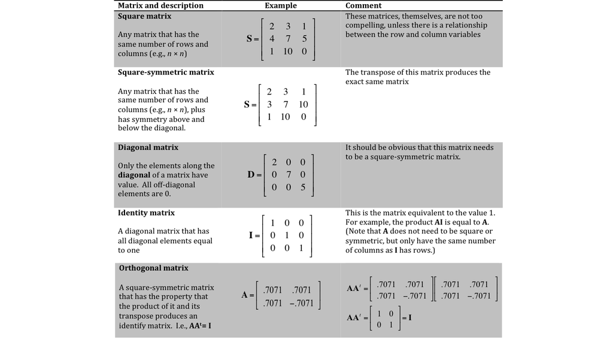

Orthogonal vectors or matrices with vectors that are also unit length, $\small\left( \mathbf{a}^T\mathbf{a}\right)^{1/2} = 1$, are also **orthornormal**.

# Special Matrices and Special Matrix Properties

### Some additional notes

- Some sources refer to “triangular” matrices. These might be symmetric matrices, where the elements above a diagonal match the elements below. However, these might refer to a matrix that looks like a symmetric matrix but values below the diagonal are all 0.
- A matrix cross-product will always produce a symmetric matrix.

# Special Matrices and Special Matrix Properties (Cont.)

### Matrix Projection

Matrix multiplication is often used for the purpose of projection of data, $\small\mathbf{Y}$. In a most technical and overly mathematical sense, projection is an alignment of data in a manifold of the data space (where Euclidean geometry is at least approximately appropriate). In a simpler sense, projection is a method of rotating, stretching, flipping, and/or scaling a data space. This is the essence of linear models - finding a constrained explanation of the data.

Two ways to understand projection:

$\small\mathbf{HY}$: where $\small\mathbf{H}$ is an $\small n \times n$ projection matrix

$\small\mathbf{YH}$: where $\small\mathbf{H}$ is a $\small p \times p$ rotation/shear/scale matrix

Both of these will make more sense with exposure to linear model uses, but for now, let’s consider what the latter does.

# Matrix Projection: Geometric Interpretations

To best understand attributes of high-dimensional data spaces and algebra applied to them, consider two-dimensional data spaces and realize the algebra can be generalized to higher dimensions.

### The Result of $\mathbf{YH}$, where $\mathbf{H}$ is a $p \times p$ matrix

[output not shown]

**Note** that $\small\mathbf{H}_{orthogonal}$ can be viewed as a rotation matrix, which makes sense in low-dimensional data spaces. For example, in a two dimension data space, it can be the same as:
$$\small\mathbf{H}_{orthogonal} = \begin{bmatrix}
\cos\theta & -\sin\theta\\
\sin\theta & \cos\theta
\end{bmatrix}$$
for a rotational angle, $\small\theta$, in a plane.

# Matrix Projection: Geometric Interpretations (Cont.)

[figure not shown]

# Matrix Inversion

- Matrices cannot be divided. Much like division of a scalar is the same as multiplication by its inverse (i.e., reciprocal), some matrices can be inverted.
- Matrix needs to be square, *non-singular*; symmetric, non-singular is optimal.
- Matrix inversion fulfills the property that $\small\mathbf{AA}^{-1} = \mathbf{I}$
- Illustration is simplest with a $\small 2 \times 2$ matrix

Let $\small\mathbf{A}$ be a $\small 2 \times 2$ matrix,
$$\small\mathbf{A} = \begin{bmatrix}
a & b \\
c & d
\end{bmatrix}$$
Then,
$$\small \mathbf{A}^{-1} = \left| \mathbf{A} \right|^{-1} \begin{bmatrix}
d & -b\\
-c & a
\end{bmatrix}$$
where $\small\left| \mathbf{A} \right| = ad-bc$

If $\small|\mathbf{A}| = 0$, the matrix is *singular* and cannot be inverted (dividing by 0 from matrices).

# Matrix Inversion: Example

$$\tiny\mathbf{A} = \begin{bmatrix}
3 & 4 \\
4 & 6
\end{bmatrix}$$

$$\tiny\left| \mathbf{A} \right| = 18-16$$
$$\tiny\left| \mathbf{A} \right|^{-1} = 0.5$$
$$\tiny\mathbf{A}^{-1} = \left| \mathbf{A} \right|^{-1} \begin{bmatrix}
d & -b\\
-c & a
\end{bmatrix} =
0.5 \begin{bmatrix}
6 & -4\\
-4 & 3
\end{bmatrix} =
\begin{bmatrix}
3 & -2\\
-2 & 1.5
\end{bmatrix}$$

Confirm (using R script)

```r
A = matrix(c(3, 4, 4, 6), nrow = 2, ncol = 2)
A
```

```
##      [,1] [,2]
## [1,]    3    4
## [2,]    4    6
```

```r
solve(A) # solve function finds inverse
```

```
##      [,1] [,2]
## [1,]    3 -2.0
## [2,]   -2  1.5
```

```r
A %*% solve(A)
```

```
##      [,1] [,2]
## [1,]    1    0
## [2,]    0    1
```

# Matrix Inversion (Cont.)

- Note, inversion with 3 × 3 matrices or larger, not a trivial exercise
- Plagiarized from Wikipedia…

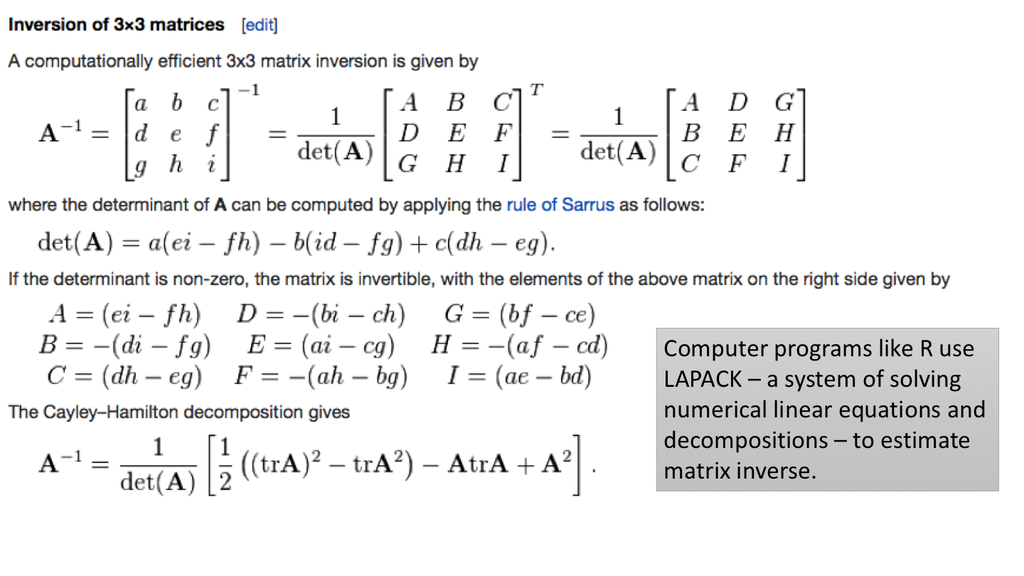

# Putting Our Knowledge to Good Use!

Matrix inversion is frequently used in statistical estimation

However, recall that a matrix must be square in order to be inverted, and data matrices ($\small n \times p$) are unlikely to be square (i.e., $\small n\neq{p}$).

But, matrix cross-products are square *and* symmetric, and are essentially the squaring of matrices.

**Thus**, matrix cross-products are invertible (and frequently used as a step before inversion).

- Consider: $\tiny\mathbf{X} = \begin{bmatrix} 1 & 0 \\ 1 & 0 \\ 1 & 0 \\ 1 & 1 \\ 1 & 1 \\ 1 & 1 \end{bmatrix}$ We calculate: $\tiny\mathbf{X^TX} =\begin{bmatrix} 1 & 1 & 1 & 1 & 1 & 1 \\ 0 & 0 & 0 & 1 & 1 & 1 \end{bmatrix} \begin{bmatrix} 1 & 0 \\ 1 & 0 \\ 1 & 0 \\ 1 & 1 \\ 1 & 1 \\ 1 & 1 \end{bmatrix} = \begin{bmatrix} 6 & 3 \\ 3 & 3 \end{bmatrix}$

Then, the matrix inverse is: $\small\mathbf{(X^TX)}^{-1}= \frac{1}{6*3 - 3*3}\begin{bmatrix} 3 & -3 \\ -3 & 6 \end{bmatrix}=\begin{bmatrix} .333 & -.333 \\ -.333 & .667 \end{bmatrix}$

# Using R scripts

```r
x1 <- rep(1, 6) # variable x1 with 6 observations
x2 <- c(rep(0, 3), rep(1,3)) # variable x2 with 6 observations
X <- as.matrix(data.frame(x1 = x1, x2 = x2))
X
```

```
##      x1 x2
## [1,]  1  0
## [2,]  1  0
## [3,]  1  0
## [4,]  1  1
## [5,]  1  1
## [6,]  1  1
```

```r
crossprod(X)
```

```
##    x1 x2
## x1  6  3
## x2  3  3
```

```r
solve(crossprod(X))
```

```
##            x1         x2
## x1  0.3333333 -0.3333333
## x2 -0.3333333  0.6666667
```

# Using R scripts (Cont.)

And while we are on the topic… Imagine that the second column is a variable, $X$, taking on the value either 0 or 1

The first column is a “dummy” variable

```r
X
```

```
##      x1 x2
## [1,]  1  0
## [2,]  1  0
## [3,]  1  0
## [4,]  1  1
## [5,]  1  1
## [6,]  1  1
```

With a little bit of mind-bending, one might notice that

$$\small\mathbf{X}^T\mathbf{X} = \begin{bmatrix}
n & \sum X\\
\sum X & \sum X^2
\end{bmatrix}$$

# A Simpler Example

Let’s reduce the $\mathbf{X}$ matrix, such that
$$\tiny\mathbf{X}_0 = \begin{bmatrix}
1\\ 1\\ 1\\ 1\\ 1\\ 1 \end{bmatrix}$$

Now find the cross-product and inverse:

```r
X0 <- X[,1] # just the first column
crossprod(X0)
```

```
##      [,1]
## [1,]    6
```

```r
solve(crossprod(X0))
```

```
##           [,1]
## [1,] 0.1666667
```

Thus, $\small\mathbf{X}_0^T\mathbf{X}_0 = n$ and $\left( \mathbf{X}_0^T\mathbf{X}_0 \right)^{-1} = n^{-1}$

# Putting Our Knowledge to Good Use! (Cont.)

Now for fun, let’s find the cross-product between $\mathbf{X}_0$ and $\mathbf{Y}$

```r
Y <- c(2, 3, 2, 5, 6, 8)
crossprod(X0, Y)
```

```
##      [,1]
## [1,]   26
```

If we examine $\small\mathbf{Y}$ again, you might notice something

```r
Y
```

```
## [1] 2 3 2 5 6 8
```

$\small\mathbf{X}_0^T\mathbf{Y}$ produces vector sums, $\sum y_i$ for each variable.

# Putting Our Knowledge to Good Use! (Cont.)

One more step! Let’s find the result of two things:

| $\small\left( \mathbf{X}_0^T\mathbf{X}_0 \right)^{-1}\mathbf{X}_0^T\mathbf{Y}$ |  | $\small\mathbf{X}_0 \left( \mathbf{X}_0^T\mathbf{X}_0 \right)^{-1}\mathbf{X}_0^T\mathbf{Y}$ |
| --- | --- | --- |

```r
solve(crossprod(X0)) %*% crossprod(X0, Y)
```

```
##          [,1]
## [1,] 4.333333
```

```r
X0 %*% solve(crossprod(X0)) %*% crossprod(X0, Y)
```

```
##          [,1]
## [1,] 4.333333
## [2,] 4.333333
## [3,] 4.333333
## [4,] 4.333333
## [5,] 4.333333
## [6,] 4.333333
```

###### The former finds a (row) vector of variable means. The latter creates a matrix of variable means for every observation in the original data matrix, $\mathbf{Y}$!

Although it might not yet be obvious, we just used the general linear model to find fitted (predicted) values for a model design that has a single mean (centroid).

# The General Linear Model

$$\huge \mathbf{Y}=\mathbf{X}\mathbf{\beta } +\mathbf{E}$$

| Component | Dimension | Description |
| --- | --- | --- |
| $\small\mathbf{Y}$ | $\small n \times p$ | Data matrix with $n$ observations for $\small p$ variables |
| $\small\mathbf{X}$ | $\small n \times k$ | Linear model design matrix with $\small n$ observations for $k$ parameters |
| $\small\mathbf{\beta}$ | $\small k \times p$ | Matrix of coefficients expressing change in values for the $\small k$ model parameters for each of $\small p$ variables |
| $\small\mathbf{E}$ | $\small n \times p$ | Matrix of residuals (error) for $\small n$ observations for $\small p$ variables |

Like any area of statistics, the coefficients for a linear model (which has parameters for variable change associated with some hypothetical process) are generally unknown but exist in a population, and are, therefore, estimated from a sample. We can solve this algebraically as the solution that would be true if there was no error in the model (i.e., $\small\mathbf{E}$ = 0). The goal is to solve for $\small\mathbf{\beta}$.

# The General Linear Model: Solving for $\small\mathbf{\beta}$

To derive the formula for $\small\mathbf{\beta}$ we do the following:

$$\small\mathbf{Y}=\mathbf{X}\mathbf{\beta }$$
$$\small\mathbf{X}^T\mathbf{Y} = \mathbf{X}^T\mathbf{X}\mathbf{\beta }$$

$$\small\left( \mathbf{X}^T\mathbf{X} \right)^{-1} \mathbf{X}^T\mathbf{Y} =
\left( \mathbf{X}^T\mathbf{X} \right)^{-1} \mathbf{X}^T\mathbf{X}\mathbf{\beta }$$
$$\small\left( \mathbf{X}^T\mathbf{X} \right)^{-1} \mathbf{X}^T\mathbf{Y} =
\mathbf{I}\mathbf{\beta }$$

$$\small\hat{\mathbf{\beta }}=\left ( \mathbf{X}^{T} \mathbf{X}\right )^{-1}\left ( \mathbf{X}^{T} \mathbf{Y}\right )$$
The ^ reminds us that this is a matrix of estimate values.

# The Linear Model: Predicted Values and Residuals

Using the linear model, predicted values are:

$$\small\hat{\mathbf{Y}}=\mathbf{X}{\mathbf{\beta}=\mathbf{X}\left ( \mathbf{X}^{T} \mathbf{X}\right )^{-1} \mathbf{X}^{T} \mathbf{Y}} = \mathbf{HY}$$

Here, the ‘hat’ matrix $\small\mathbf{H}$ is an $\small n\times n$ projection matrix. This operation finds the predicted values $\small\hat{\mathbf{Y}}$ for the linear model specified in $\small\mathbf{X}$.

Thus, residuals of the model are found as:

$$\small\mathbf{E} = \mathbf{Y} - \hat{\mathbf{Y}}=\mathbf{Y} - \mathbf{H}\mathbf{Y} =\left(\mathbf{I}-\mathbf{H}\right)\mathbf{Y}$$

# A Comparison of Models

Now we are in a position to compare models.

$\tiny\mathbf{X}_R = \begin{bmatrix} 1\\ 1\\ 1\\ 1\\ 1\\ 1 \end{bmatrix}$ & $\tiny\mathbf{X}_F = \begin{bmatrix} 1 & 0 \\ 1 & 0 \\ 1 & 0 \\ 1 & 1 \\ 1 & 1 \\ 1 & 1 \end{bmatrix}$

Let’s compare the fit of the data to both $\small\mathbf{X}_{R}$ and $\small\mathbf{X}_{F}$:

| Estimate | $\small\mathbf{X}_{R}$ | $\small\mathbf{X}_{F}$ |
| --- | --- | --- |
| Coefficients | $\tiny\hat{\mathbf{\beta_R}}=\left ( \mathbf{X}_R^{T} \mathbf{X}_R\right )^{-1}\left ( \mathbf{X}_R^{T} \mathbf{Y}\right )$ | $\tiny\hat{\mathbf{\beta_F}}=\left ( \mathbf{X}_F^{T} \mathbf{X}_F\right )^{-1}\left ( \mathbf{X}_F^{T} \mathbf{Y}\right )$ |
| Predicted Values | $\small\hat{\mathbf{Y}}_R=\mathbf{X}_R\hat{\mathbf{\beta}}_R$ | $\small\hat{\mathbf{Y}}_F=\mathbf{X}_F\hat{\mathbf{\beta}}_F$ |
| Model Residuals | $\small\hat{\mathbf{E}}_R=\mathbf{Y}-\hat{\mathbf{Y}}_R$ | $\small\hat{\mathbf{E}}_F=\mathbf{Y}-\hat{\mathbf{Y}}_F$ |
| Model Residual Error ($\small{SSE}$) | $\small\mathbf{S}_R=\hat{\mathbf{E}}_R^T\hat{\mathbf{E}}_R$ | $\small\mathbf{S}_F=\hat{\mathbf{E}}_F^T\hat{\mathbf{E}}_F$ |

Significance test based on: $\small{F}=\frac{(\mathbf{S}_R -\mathbf{S}_F) /(k-1) }{\mathbf{S}_F /(n-k)}$

$\small{F}$-ratio is then evaluated using parametric methods or empirical sampling distributions from RRPP

# The Linear Model: Comments

The linear model allows us to fit our data to various models: $\small\mathbf{X}_F$ & $\small\mathbf{X}_F$

The fit to these models is compared statistically using parametric distributions or empirical sampling distributions obtained via resampling (RRPP)

**BOTH** ANOVA and regression models are encapsulated by the linear model: the difference is what types of variables are found in $\small\mathbf{X}$

Next time: Moving this to multivariate $\small\mathbf{Y}$ data!